# Calories Prediction — Analysis & Visualization

## Project Setup & Imports

### English

We add the project root to `sys.path` so the notebook can import directly from `src/`, exactly like the scripts in `src/` import from each other. This works regardless of whether the notebook is launched from `notebooks/` or from the project root.

### العربية

نقوم بإضافة جذر المشروع إلى `sys.path` حتى يتمكن الدفتر من الاستيراد مباشرة من مجلد `src/`، تمامًا كما تستورد الملفات داخل `src/` من بعضها البعض. يعمل هذا بغض النظر عمّا إذا تم تشغيل الدفتر من `notebooks/` أو من جذر المشروع.

```python
import sys
from pathlib import Path

import pandas as pd
from IPython.display import display, Image

# ---------------------------------------------------------------------------
# Make src/ importable, regardless of where the notebook is launched from
# ---------------------------------------------------------------------------
NOTEBOOK_DIR = Path.cwd()
PROJECT_ROOT = NOTEBOOK_DIR.parent if NOTEBOOK_DIR.name == "notebooks" else NOTEBOOK_DIR

if str(PROJECT_ROOT) not in sys.path:
    sys.path.insert(0, str(PROJECT_ROOT))

# ---------------------------------------------------------------------------
# Project modules
# ---------------------------------------------------------------------------
from src.data_loader import (
    load_raw_data,
    load_processed_data,
    get_dataset_info,
    PROCESSED_DATA_FILE,
)

from src.data_cleaning import run_cleaning_pipeline

from src.data_analysis import (
    generate_analysis_report,
    analyze_target,
    get_correlation,
)

from src.visualization import (
    FIGURES_DIR,
    plot_histogram,
    plot_boxplot,
    plot_scatter,
    plot_regression,
    plot_correlation_heatmap,
    plot_bar_chart,
    plot_line,
    plot_pairplot,
    plot_countplot,
    plot_calories_distribution,
    plot_calories_vs_time,
    plot_calories_vs_distance,
    plot_calories_vs_heart_rate,
    plot_calories_vs_weight,
    plot_violin,
    plot_kde,
    plot_target_correlations,
    plot_calories_by_gender,
    plot_scatter_by_gender,
)

pd.set_option("display.max_columns", None)

print(f"Project root : {PROJECT_ROOT}")
print(f"Figures dir  : {FIGURES_DIR}")
```

```
Project root : c:\Users\ayman\OneDrive\Desktop\calories-prediction
Figures dir  : C:\Users\ayman\OneDrive\Desktop\calories-prediction\reports\figures
```

### Display Helper

**English:** `src/visualization.py` already saves every figure to `reports/figures/` and closes it (so the pipeline can run headlessly). To still *see* each figure inline in this notebook, we add one small helper that shows whichever PNG(s) were just created, right after calling the plotting function. No plotting logic lives here — it only displays what `src/visualization.py` already saved.

**العربي:** تقوم `src/visualization.py` بالفعل بحفظ كل رسم في `reports/figures/` وإغلاقه (حتى يعمل خط الأنابيب دون واجهة رسومية). لعرض كل رسم داخل هذا الدفتر مباشرة، نضيف دالة مساعدة صغيرة تعرض ملف/ملفات PNG التي تم إنشاؤها للتو، مباشرة بعد استدعاء دالة الرسم. لا يوجد أي منطق رسم هنا — فهي تعرض فقط ما قامت `src/visualization.py` بحفظه بالفعل.

```python
def call_and_show(func, *args, **kwargs):
    """
    Call a plotting function from src.visualization, then display
    whichever PNG file(s) it just saved into FIGURES_DIR.
    """

    before = {f: f.stat().st_mtime for f in FIGURES_DIR.glob("*.png")}

    func(*args, **kwargs)

    after = {f: f.stat().st_mtime for f in FIGURES_DIR.glob("*.png")}

    new_or_updated = [
        f for f, mtime in after.items()
        if f not in before or before[f] != mtime
    ]

    for f in sorted(new_or_updated):
        print(f"Figure saved: {f}")
        display(Image(filename=str(f)))
```

## Load Raw Dataset

### English

We load the raw dataset using `load_raw_data()` from `src/data_loader.py`, which resolves `data/raw/dataset.csv` relative to the project root itself (not the current working directory), so it works no matter where the notebook is run from.

### العربية

نقوم بتحميل البيانات الخام باستخدام `load_raw_data()` من `src/data_loader.py`، والتي تحدد مسار `data/raw/dataset.csv` بالنسبة لجذر المشروع نفسه (وليس مجلد العمل الحالي)، لذلك تعمل بغض النظر عن مكان تشغيل الدفتر.

```python
df_raw = load_raw_data()

info = get_dataset_info(df_raw)

for key, value in info.items():
    if key != "column_names":
        print(f"{key}: {value}")

print("\nColumns:")
for column in info["column_names"]:
    print(f"- {column}")

df_raw.head()
```

```
rows: 200
columns: 10
total_values: 2000
missing_values: 0
duplicate_rows: 0

Columns:
- Gender
- Age
- Height(cm)
- Weight(kg)
- BMI
- Running Time(min)
- Running Speed(km/h)
- Distance(km)
- Average Heart Rate
- Calories Burned
```

|  | Gender | Age | Height(cm) | Weight(kg) | BMI | Running Time(min) | Running Speed(km/h) | Distance(km) | Average Heart Rate | Calories Burned |
| --- | --- | --- | --- | --- | --- | --- | --- | --- | --- | --- |
| 0 | Male | 49 | 184 | 74 | 20.4 | 78 | 9.5 | 3.00 | 139 | 973 |
| 1 | Female | 56 | 182 | 70 | 23.2 | 98 | 10.2 | 5.23 | 165 | 494 |
| 2 | Male | 49 | 170 | 85 | 27.4 | 91 | 10.4 | 7.61 | 134 | 954 |
| 3 | Male | 21 | 181 | 59 | 24.0 | 89 | 13.4 | 14.19 | 144 | 570 |
| 4 | Male | 47 | 172 | 86 | 29.8 | 79 | 9.8 | 3.84 | 149 | 385 |

## Exploratory Analysis (Before Cleaning)

### English

`generate_analysis_report()` from `src/data_analysis.py` runs every check in one call: basic info, missing values, duplicates, numerical/categorical columns, full statistics, unique-value counts, categorical summary, correlation matrix, and an IQR-based outlier count per column. We inspect the parts most relevant before cleaning: basic info, missing values, duplicates, and outliers.

### العربية

تقوم `generate_analysis_report()` من `src/data_analysis.py` بتنفيذ جميع الفحوصات في استدعاء واحد: المعلومات الأساسية، القيم المفقودة، التكرارات، الأعمدة الرقمية/الفئوية، الإحصاءات الكاملة، عدد القيم الفريدة، الملخص الفئوي، مصفوفة الارتباط، وعدد القيم المتطرفة لكل عمود بطريقة IQR. نفحص هنا الأجزاء الأكثر أهمية قبل التنظيف: المعلومات الأساسية، القيم المفقودة، التكرارات، والقيم المتطرفة.

```python
raw_report = generate_analysis_report(df_raw)

print("Basic info:")
for key, value in raw_report["basic_info"].items():
    print(f"  {key}: {value}")

print("\nMissing values (before cleaning):")
print(raw_report["missing_values"])

print(f"\nDuplicate rows (before cleaning): {raw_report['duplicates']}")
```

```
Basic info:
  rows: 200
  columns: 10
  total_values: 2000
  duplicate_rows: 0
  missing_values: 0

Missing values (before cleaning):
Series([], dtype: int64)

Duplicate rows (before cleaning): 0
```

```python
print("Outlier counts per numerical column (IQR method, before cleaning):")
raw_report["outliers"]
```

```
Outlier counts per numerical column (IQR method, before cleaning):
```

```
Age                    0
Height(cm)             0
Weight(kg)             0
BMI                    0
Running Time(min)      0
Running Speed(km/h)    0
Distance(km)           0
Average Heart Rate     0
Calories Burned        0
dtype: int64
```

```python
raw_report["statistics"]
```

|  | count | mean | median | mode | min | max | range | std | variance | Q1 | Q2 | Q3 | IQR | 90_percentile | 95_percentile | 99_percentile |
| --- | --- | --- | --- | --- | --- | --- | --- | --- | --- | --- | --- | --- | --- | --- | --- | --- |
| Age | 200 | 41.38500 | 44.000 | 50.00 | 18.0 | 64.00 | 46.00 | 13.225785 | 174.921382 | 30.00 | 44.000 | 52.0000 | 22.0000 | 58.000 | 61.0000 | 63.0000 |
| Height(cm) | 200 | 175.09500 | 175.000 | 175.00 | 150.0 | 199.00 | 49.00 | 14.266170 | 203.523593 | 163.75 | 175.000 | 186.0000 | 22.2500 | 194.100 | 197.0000 | 199.0000 |
| Weight(kg) | 200 | 75.18500 | 74.500 | 77.00 | 50.0 | 99.00 | 49.00 | 14.106585 | 198.995754 | 62.00 | 74.500 | 87.0000 | 25.0000 | 95.100 | 98.0000 | 99.0000 |
| BMI | 200 | 24.24400 | 24.600 | 19.50 | 18.5 | 30.00 | 11.50 | 3.243558 | 10.520667 | 21.55 | 24.600 | 27.0000 | 5.4500 | 28.510 | 29.1050 | 29.8000 |
| Running Time(min) | 200 | 74.34000 | 74.500 | 58.00 | 30.0 | 119.00 | 89.00 | 25.028916 | 626.446633 | 55.00 | 74.500 | 95.0000 | 40.0000 | 107.300 | 115.0500 | 119.0000 |
| Running Speed(km/h) | 200 | 11.34150 | 11.350 | 11.20 | 7.0 | 15.00 | 8.00 | 2.167769 | 4.699224 | 9.80 | 11.350 | 13.1250 | 3.3250 | 14.200 | 14.7000 | 14.9000 |
| Distance(km) | 200 | 8.92655 | 8.825 | 13.23 | 3.0 | 14.96 | 11.96 | 3.819304 | 14.587084 | 5.38 | 8.825 | 12.6625 | 7.2825 | 13.901 | 14.4925 | 14.8802 |
| Average Heart Rate | 200 | 149.82000 | 150.500 | 139.00 | 121.0 | 179.00 | 58.00 | 16.949158 | 287.273970 | 135.00 | 150.500 | 164.2500 | 29.2500 | 173.100 | 177.0000 | 179.0000 |
| Calories Burned | 200 | 584.08500 | 554.000 | 200.00 | 200.0 | 996.00 | 796.00 | 228.289659 | 52116.168618 | 395.75 | 554.000 | 791.5000 | 395.7500 | 903.300 | 954.1000 | 993.0300 |

## Data Cleaning

### English

`run_cleaning_pipeline()` from `src/data_cleaning.py` performs the full sequence — standardize column names, convert numerical columns, clean `Gender` values, fill missing values (median/mode), drop duplicates, and remove invalid/impossible values — then saves the result to `data/processed/dataset_clean.csv` (via `PROCESSED_DATA_FILE`, imported from `src/data_loader.py`) and returns a before/after cleaning report.

### العربية

تقوم `run_cleaning_pipeline()` من `src/data_cleaning.py` بتنفيذ التسلسل الكامل — توحيد أسماء الأعمدة، تحويل الأعمدة الرقمية، تنظيف قيم `Gender`، تعبئة القيم المفقودة (بالوسيط/المنوال)، حذف التكرارات، وإزالة القيم غير الصالحة/المستحيلة — ثم تحفظ النتيجة في `data/processed/dataset_clean.csv` (عبر `PROCESSED_DATA_FILE` المستوردة من `src/data_loader.py`) وتُرجع تقريرًا لما قبل وبعد التنظيف.

```python
cleaned_df, cleaning_report = run_cleaning_pipeline(
    df_raw,
    output_path=PROCESSED_DATA_FILE,
)

for key, value in cleaning_report.items():
    print(f"{key}: {value}")
```

```
Cleaned dataset saved to: C:\Users\ayman\OneDrive\Desktop\calories-prediction\data\processed\dataset_clean.csv
original_rows: 200
cleaned_rows: 200
rows_removed: 0
original_columns: 10
cleaned_columns: 10
missing_values_before: 0
missing_values_after: 0
duplicates_before: 0
duplicates_after: 0
```

## Load Processed Dataset

### English

We reload the saved file with `load_processed_data()` rather than reusing `cleaned_df` in memory, to confirm the file on disk (the one every later stage of the project will actually read) matches what the pipeline produced.

### العربية

نقوم بإعادة تحميل الملف المحفوظ باستخدام `load_processed_data()` بدلاً من الاعتماد على `cleaned_df` في الذاكرة، للتأكد من أن الملف الموجود على القرص (وهو ما ستقرأه فعليًا كل مرحلة لاحقة في المشروع) يطابق ما أنتجه خط الأنابيب.

```python
df = load_processed_data()

print(f"Shape: {df.shape}")
df.head()
```

```
Shape: (200, 10)
```

|  | Gender | Age | Height(cm) | Weight(kg) | BMI | Running Time(min) | Running Speed(km/h) | Distance(km) | Average Heart Rate | Calories Burned |
| --- | --- | --- | --- | --- | --- | --- | --- | --- | --- | --- |
| 0 | Male | 49 | 184 | 74 | 20.4 | 78 | 9.5 | 3.00 | 139 | 973 |
| 1 | Female | 56 | 182 | 70 | 23.2 | 98 | 10.2 | 5.23 | 165 | 494 |
| 2 | Male | 49 | 170 | 85 | 27.4 | 91 | 10.4 | 7.61 | 134 | 954 |
| 3 | Male | 21 | 181 | 59 | 24.0 | 89 | 13.4 | 14.19 | 144 | 570 |
| 4 | Male | 47 | 172 | 86 | 29.8 | 79 | 9.8 | 3.84 | 149 | 385 |

## Post-Cleaning Analysis

### English

We re-run the target analysis and correlation matrix on the cleaned data using `analyze_target()` and `get_correlation()` from `src/data_analysis.py`.

### العربية

نعيد تشغيل تحليل المتغير المستهدف ومصفوفة الارتباط على البيانات النظيفة باستخدام `analyze_target()` و `get_correlation()` من `src/data_analysis.py`.

```python
analyze_target(df, "Calories Burned")
```

```
count         200.000000
mean          584.085000
median        554.000000
mode          200.000000
min           200.000000
max           996.000000
range         796.000000
std           228.289659
variance    52116.168618
Q1            395.750000
Q2            554.000000
Q3            791.500000
IQR           395.750000
dtype: float64
```

```python
correlation_matrix = get_correlation(df)
correlation_matrix
```

|  | Age | Height(cm) | Weight(kg) | BMI | Running Time(min) | Running Speed(km/h) | Distance(km) | Average Heart Rate | Calories Burned |
| --- | --- | --- | --- | --- | --- | --- | --- | --- | --- |
| Age | 1.000000 | -0.115622 | -0.062736 | -0.036499 | 0.008984 | -0.113733 | -0.020051 | -0.115899 | 0.035348 |
| Height(cm) | -0.115622 | 1.000000 | -0.030276 | -0.115931 | 0.112313 | -0.028401 | 0.067200 | 0.062085 | 0.100808 |
| Weight(kg) | -0.062736 | -0.030276 | 1.000000 | -0.050567 | -0.109841 | 0.061732 | 0.018295 | 0.017206 | 0.070512 |
| BMI | -0.036499 | -0.115931 | -0.050567 | 1.000000 | -0.039732 | -0.106841 | 0.144888 | -0.046920 | -0.059128 |
| Running Time(min) | 0.008984 | 0.112313 | -0.109841 | -0.039732 | 1.000000 | -0.061102 | -0.056769 | -0.035617 | -0.056699 |
| Running Speed(km/h) | -0.113733 | -0.028401 | 0.061732 | -0.106841 | -0.061102 | 1.000000 | 0.008205 | -0.010710 | 0.013207 |
| Distance(km) | -0.020051 | 0.067200 | 0.018295 | 0.144888 | -0.056769 | 0.008205 | 1.000000 | 0.041554 | -0.051363 |
| Average Heart Rate | -0.115899 | 0.062085 | 0.017206 | -0.046920 | -0.035617 | -0.010710 | 0.041554 | 1.000000 | 0.014701 |
| Calories Burned | 0.035348 | 0.100808 | 0.070512 | -0.059128 | -0.056699 | 0.013207 | -0.051363 | 0.014701 | 1.000000 |

## Visualizations

### English

Every chart below is produced entirely by `src/visualization.py`; this notebook just calls each function (through `call_and_show`) and displays the saved PNG. Numerical features are handled with a loop so adding a new feature to the project does not require adding a new cell here.

### العربية

كل رسم أدناه يتم إنتاجه بالكامل بواسطة `src/visualization.py`؛ هذا الدفتر فقط يستدعي كل دالة (عبر `call_and_show`) ويعرض ملف PNG المحفوظ. تتم معالجة الخصائص الرقمية عبر حلقة تكرار حتى لا تتطلب إضافة خاصية جديدة للمشروع إضافة خلية جديدة هنا.

```python
numerical_features = [
    "Age",
    "Height(cm)",
    "Weight(kg)",
    "BMI",
    "Running Time(min)",
    "Running Speed(km/h)",
    "Distance(km)",
    "Average Heart Rate",
    "Calories Burned",
]
```

### Target Distribution — Calories Burned

`plot_calories_distribution()`

```
Figure saved: C:\Users\ayman\OneDrive\Desktop\calories-prediction\reports\figures\calories_burned_distribution.png
Figure saved: C:\Users\ayman\OneDrive\Desktop\calories-prediction\reports\figures\calories_burned_distribution.png
```

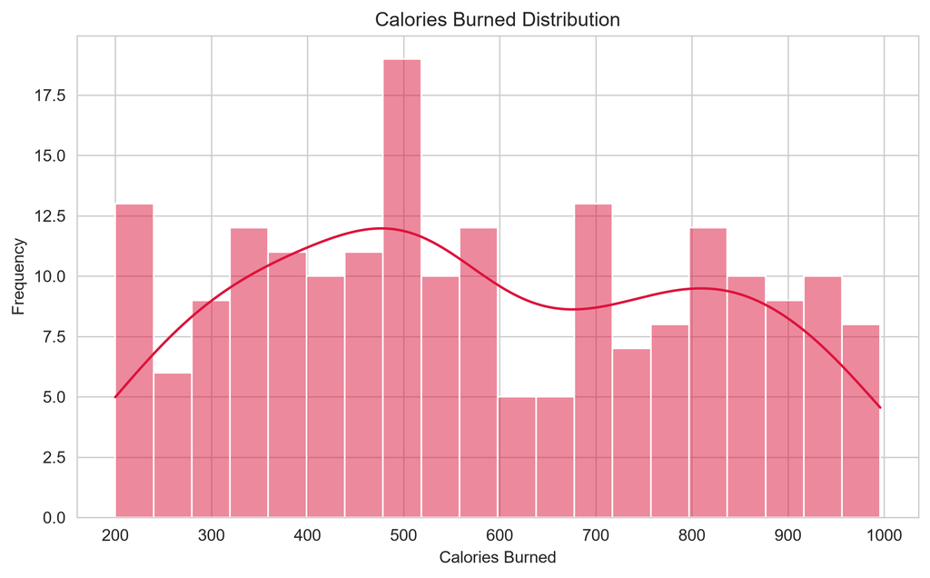

```python
call_and_show(plot_calories_distribution, df)
```

### Numerical Feature Distributions — `plot_histogram()`

```
Figure saved: C:\Users\ayman\OneDrive\Desktop\calories-prediction\reports\figures\histogram_Age.png
Figure saved: C:\Users\ayman\OneDrive\Desktop\calories-prediction\reports\figures\histogram_Age.png
```

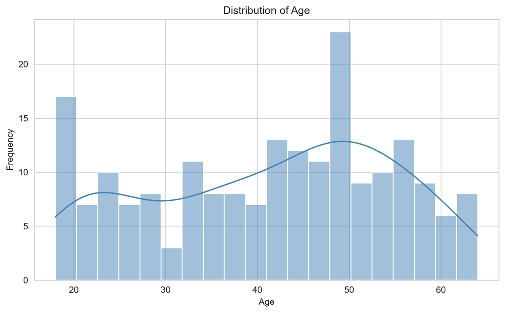

```
Figure saved: C:\Users\ayman\OneDrive\Desktop\calories-prediction\reports\figures\histogram_Height(cm).png
Figure saved: C:\Users\ayman\OneDrive\Desktop\calories-prediction\reports\figures\histogram_Height(cm).png
```

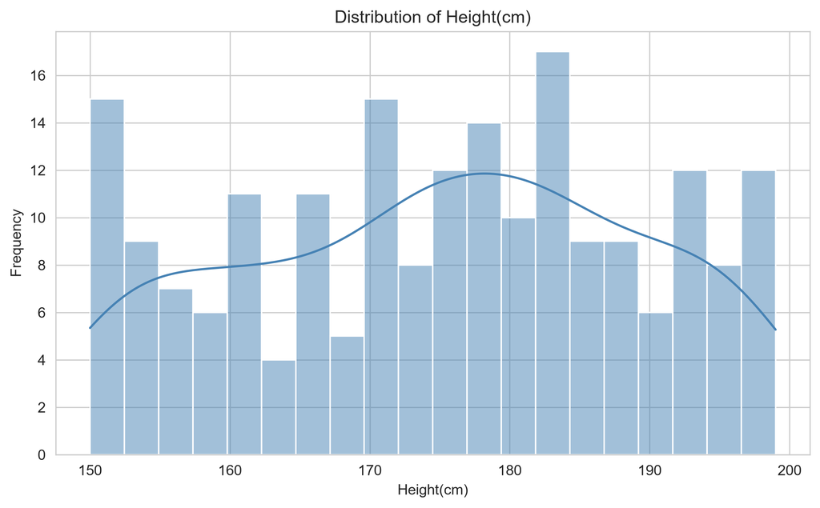

```
Figure saved: C:\Users\ayman\OneDrive\Desktop\calories-prediction\reports\figures\histogram_Weight(kg).png
Figure saved: C:\Users\ayman\OneDrive\Desktop\calories-prediction\reports\figures\histogram_Weight(kg).png
```

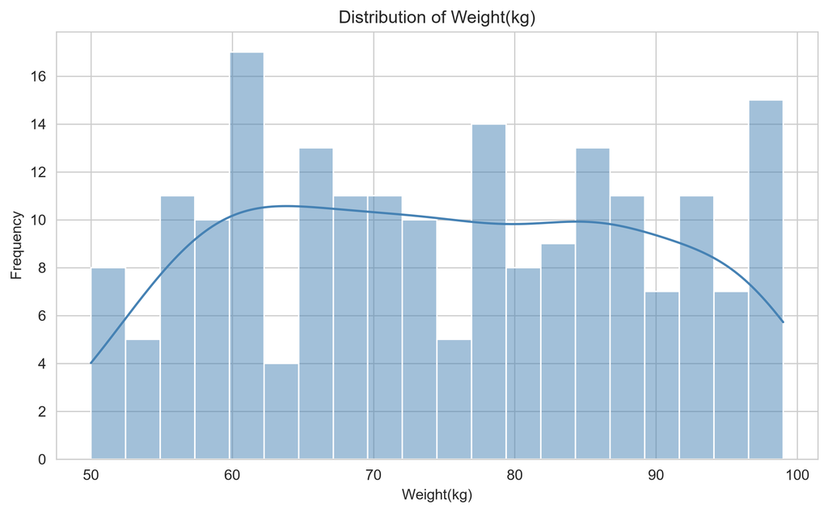

```
Figure saved: C:\Users\ayman\OneDrive\Desktop\calories-prediction\reports\figures\histogram_BMI.png
Figure saved: C:\Users\ayman\OneDrive\Desktop\calories-prediction\reports\figures\histogram_BMI.png
```

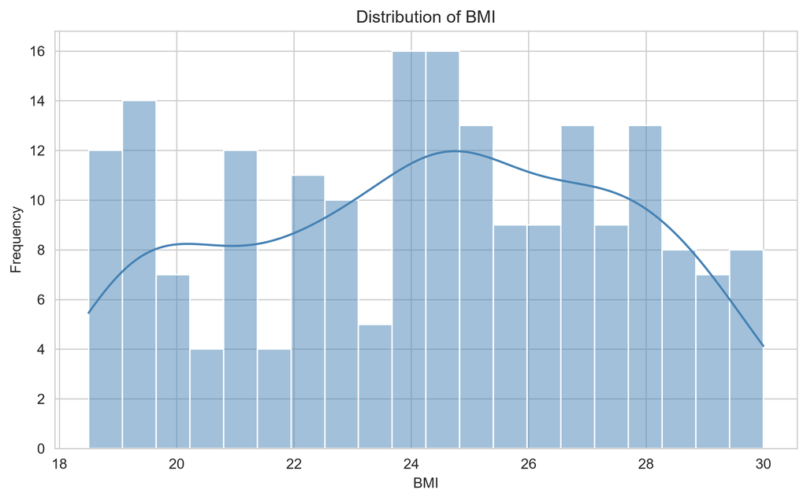

```
Figure saved: C:\Users\ayman\OneDrive\Desktop\calories-prediction\reports\figures\histogram_Running_Time(min).png
Figure saved: C:\Users\ayman\OneDrive\Desktop\calories-prediction\reports\figures\histogram_Running_Time(min).png
```

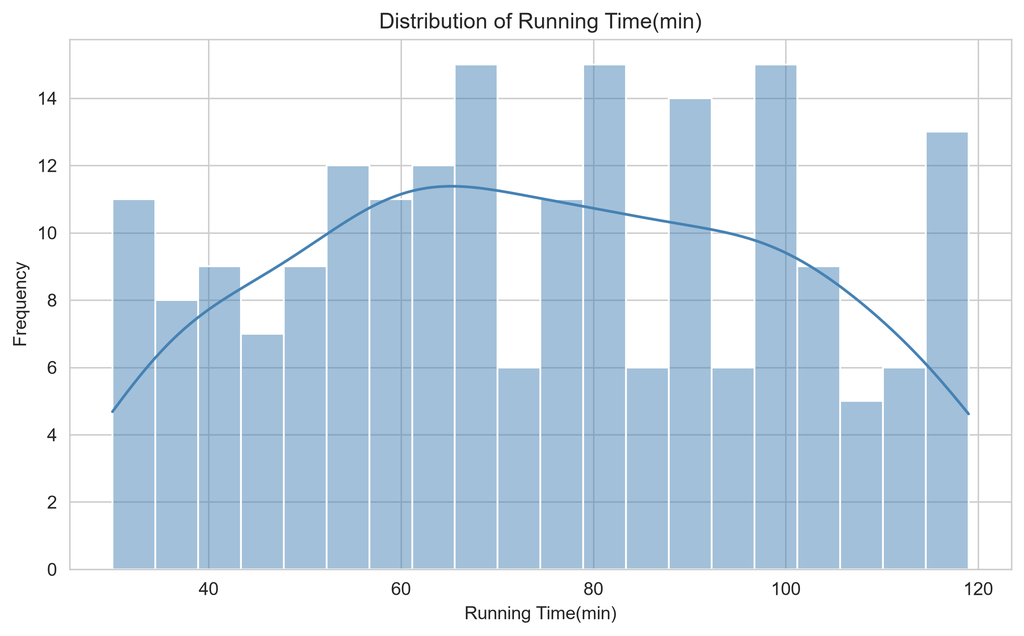

```
Figure saved: C:\Users\ayman\OneDrive\Desktop\calories-prediction\reports\figures\histogram_Running_Speed(km_h).png
Figure saved: C:\Users\ayman\OneDrive\Desktop\calories-prediction\reports\figures\histogram_Running_Speed(km_h).png
```

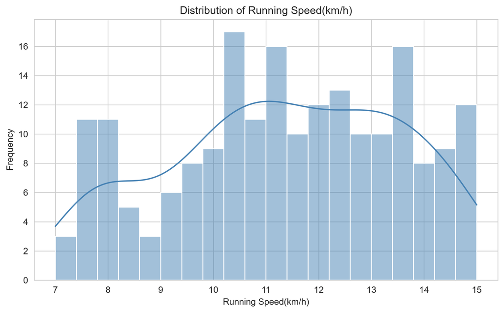

```
Figure saved: C:\Users\ayman\OneDrive\Desktop\calories-prediction\reports\figures\histogram_Distance(km).png
Figure saved: C:\Users\ayman\OneDrive\Desktop\calories-prediction\reports\figures\histogram_Distance(km).png
```

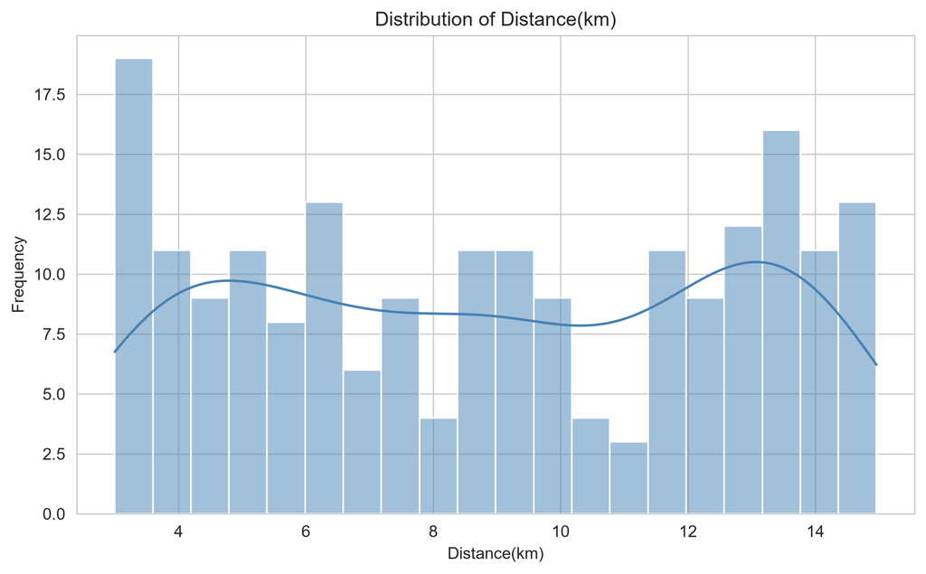

```
Figure saved: C:\Users\ayman\OneDrive\Desktop\calories-prediction\reports\figures\histogram_Average_Heart_Rate.png
Figure saved: C:\Users\ayman\OneDrive\Desktop\calories-prediction\reports\figures\histogram_Average_Heart_Rate.png
```

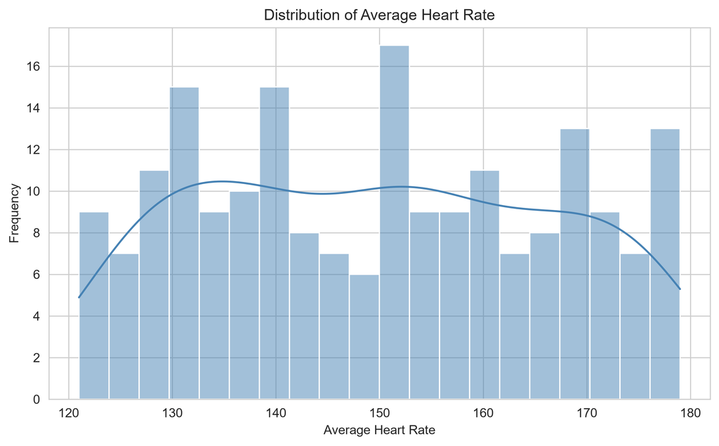

```
Figure saved: C:\Users\ayman\OneDrive\Desktop\calories-prediction\reports\figures\histogram_Calories_Burned.png
Figure saved: C:\Users\ayman\OneDrive\Desktop\calories-prediction\reports\figures\histogram_Calories_Burned.png
```

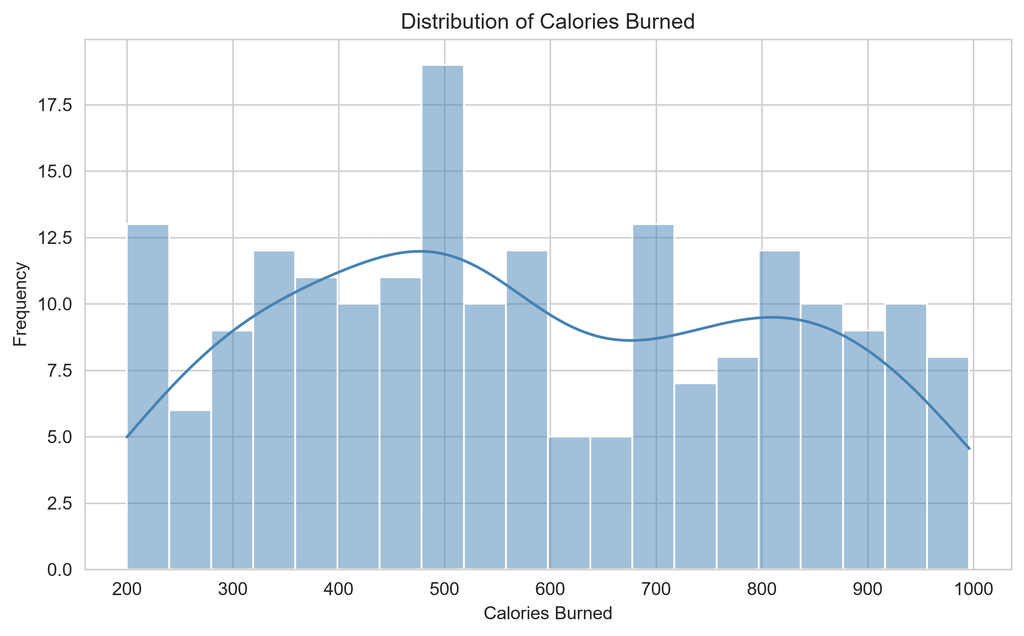

```python
for feature in numerical_features:
    call_and_show(plot_histogram, df, feature)
```

### Numerical Feature Boxplots — `plot_boxplot()`

```
Figure saved: C:\Users\ayman\OneDrive\Desktop\calories-prediction\reports\figures\boxplot_Age.png
Figure saved: C:\Users\ayman\OneDrive\Desktop\calories-prediction\reports\figures\boxplot_Age.png
```

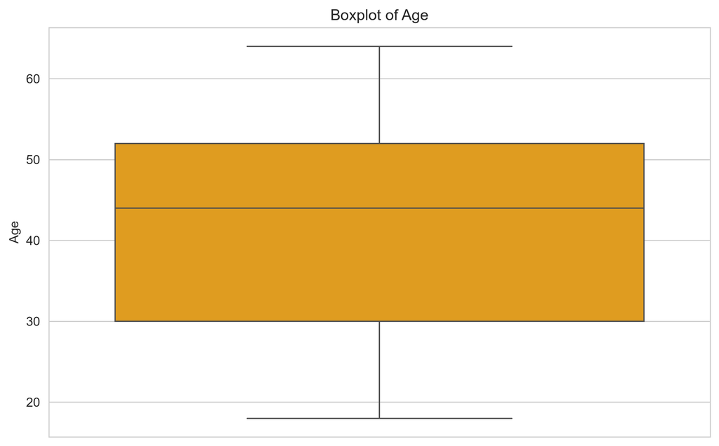

```
Figure saved: C:\Users\ayman\OneDrive\Desktop\calories-prediction\reports\figures\boxplot_Height(cm).png
Figure saved: C:\Users\ayman\OneDrive\Desktop\calories-prediction\reports\figures\boxplot_Height(cm).png
```

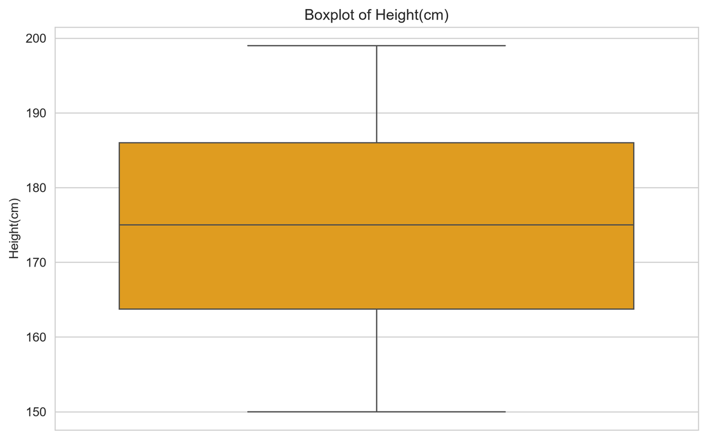

```
Figure saved: C:\Users\ayman\OneDrive\Desktop\calories-prediction\reports\figures\boxplot_Weight(kg).png
Figure saved: C:\Users\ayman\OneDrive\Desktop\calories-prediction\reports\figures\boxplot_Weight(kg).png
```

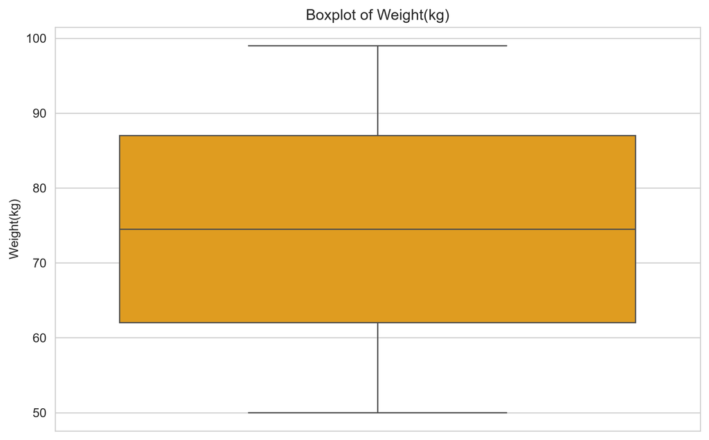

```
Figure saved: C:\Users\ayman\OneDrive\Desktop\calories-prediction\reports\figures\boxplot_BMI.png
Figure saved: C:\Users\ayman\OneDrive\Desktop\calories-prediction\reports\figures\boxplot_BMI.png
```

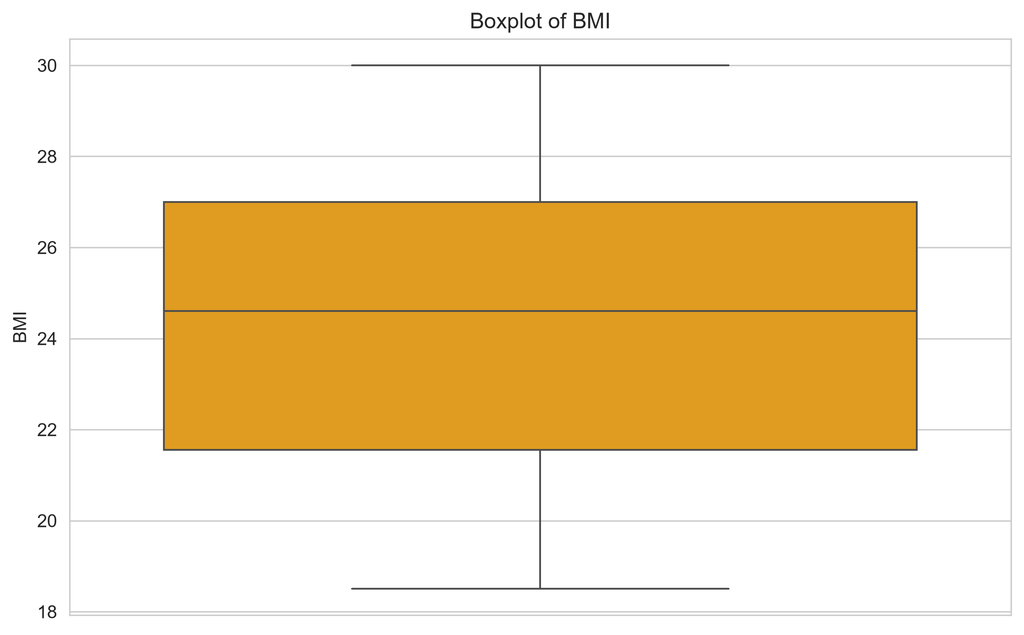

```
Figure saved: C:\Users\ayman\OneDrive\Desktop\calories-prediction\reports\figures\boxplot_Running_Time(min).png
Figure saved: C:\Users\ayman\OneDrive\Desktop\calories-prediction\reports\figures\boxplot_Running_Time(min).png
```

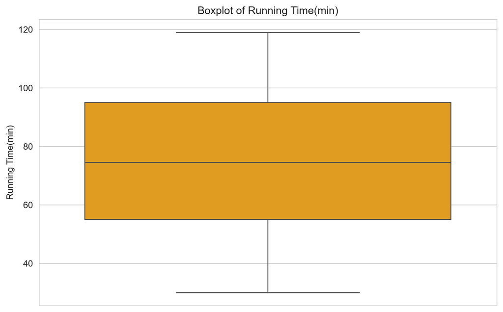

```
Figure saved: C:\Users\ayman\OneDrive\Desktop\calories-prediction\reports\figures\boxplot_Running_Speed(km_h).png
Figure saved: C:\Users\ayman\OneDrive\Desktop\calories-prediction\reports\figures\boxplot_Running_Speed(km_h).png
```

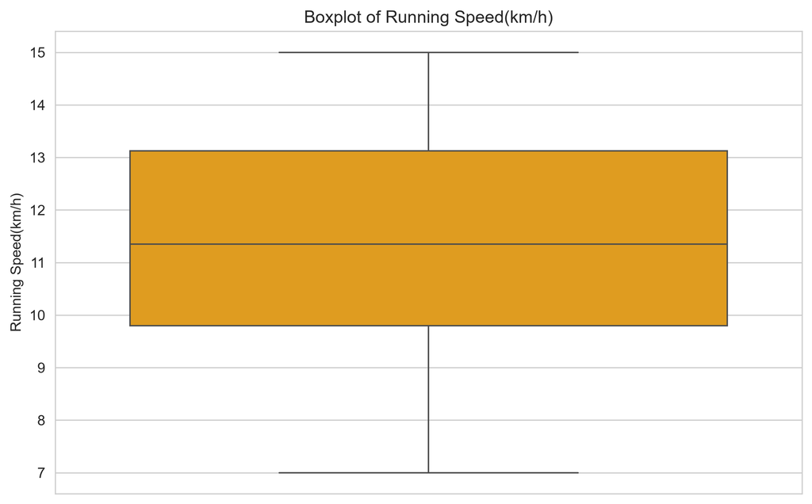

```
Figure saved: C:\Users\ayman\OneDrive\Desktop\calories-prediction\reports\figures\boxplot_Distance(km).png
Figure saved: C:\Users\ayman\OneDrive\Desktop\calories-prediction\reports\figures\boxplot_Distance(km).png
```

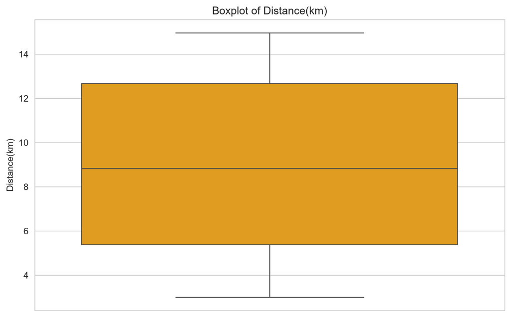

```
Figure saved: C:\Users\ayman\OneDrive\Desktop\calories-prediction\reports\figures\boxplot_Average_Heart_Rate.png
Figure saved: C:\Users\ayman\OneDrive\Desktop\calories-prediction\reports\figures\boxplot_Average_Heart_Rate.png
```

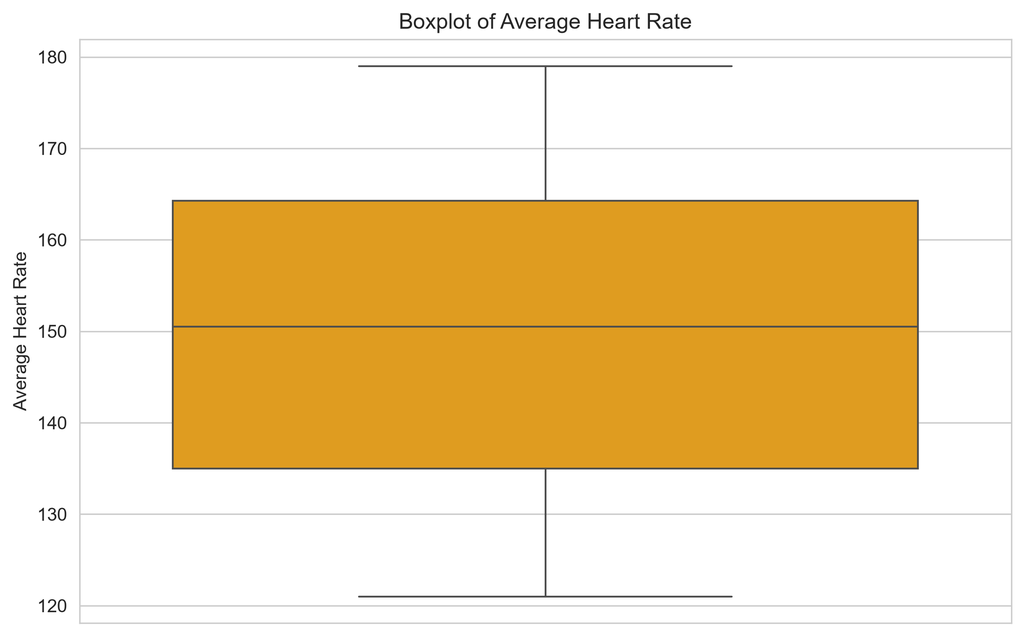

```
Figure saved: C:\Users\ayman\OneDrive\Desktop\calories-prediction\reports\figures\boxplot_Calories_Burned.png
Figure saved: C:\Users\ayman\OneDrive\Desktop\calories-prediction\reports\figures\boxplot_Calories_Burned.png
```

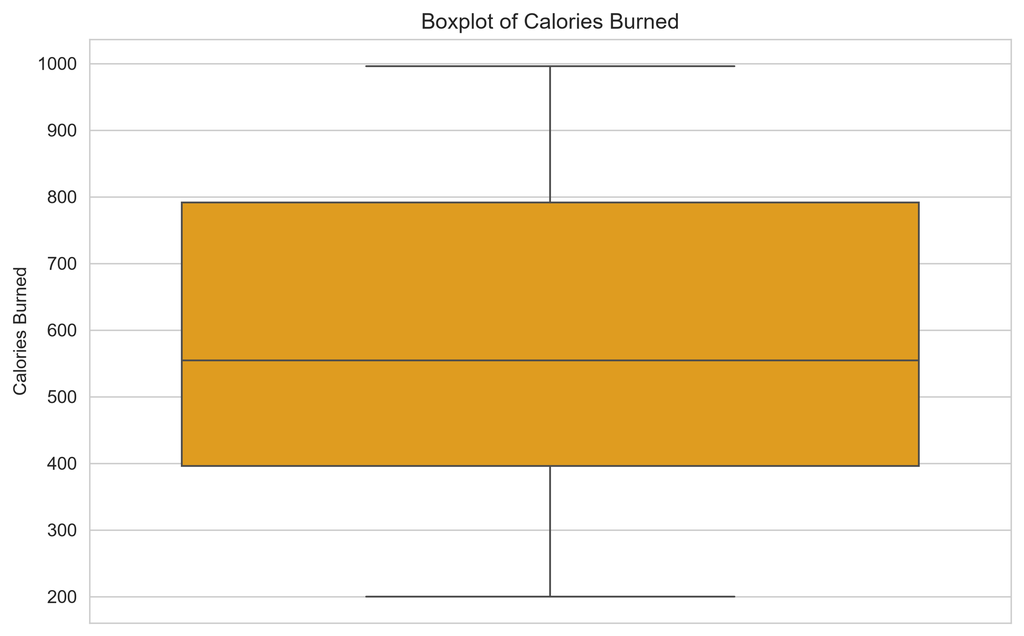

```python
for feature in numerical_features:
    call_and_show(plot_boxplot, df, feature)
```

### Gender Distribution — `plot_countplot()`

```
Figure saved: C:\Users\ayman\OneDrive\Desktop\calories-prediction\reports\figures\countplot_Gender.png
Figure saved: C:\Users\ayman\OneDrive\Desktop\calories-prediction\reports\figures\countplot_Gender.png
```

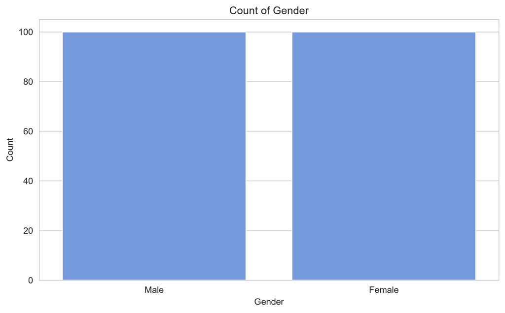

```
Gender
Male      100
Female    100
Name: count, dtype: int64
```

```python
call_and_show(plot_countplot, df, "Gender")
print(df["Gender"].value_counts())
```

### Calories Burned by Gender — `plot_calories_by_gender()` / `plot_violin()`

```
Figure saved: C:\Users\ayman\OneDrive\Desktop\calories-prediction\reports\figures\calories_by_gender.png
Figure saved: C:\Users\ayman\OneDrive\Desktop\calories-prediction\reports\figures\calories_by_gender.png
```

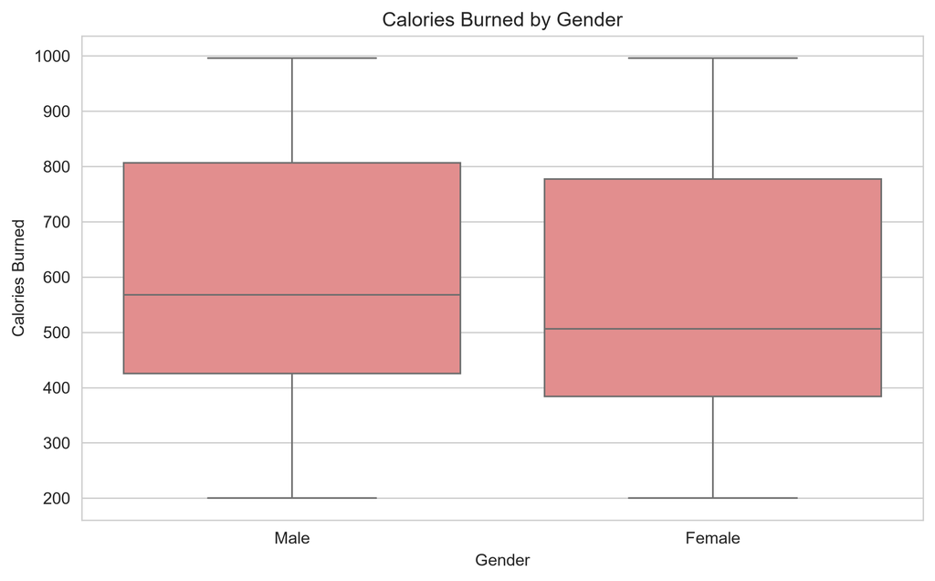

```python
call_and_show(plot_calories_by_gender, df)
```

```
Figure saved: C:\Users\ayman\OneDrive\Desktop\calories-prediction\reports\figures\violin_Calories_Burned.png
Figure saved: C:\Users\ayman\OneDrive\Desktop\calories-prediction\reports\figures\violin_Calories_Burned.png
```

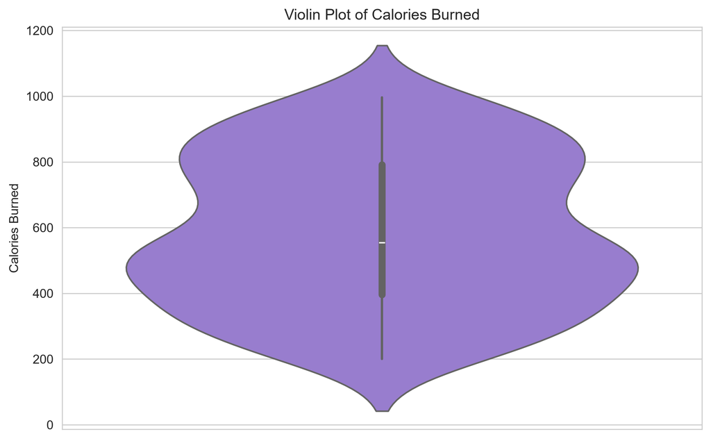

```python
call_and_show(plot_violin, df, "Calories Burned")
```

### Calories Burned — KDE — `plot_kde()`

```
Figure saved: C:\Users\ayman\OneDrive\Desktop\calories-prediction\reports\figures\kde_Calories_Burned.png
Figure saved: C:\Users\ayman\OneDrive\Desktop\calories-prediction\reports\figures\kde_Calories_Burned.png
```

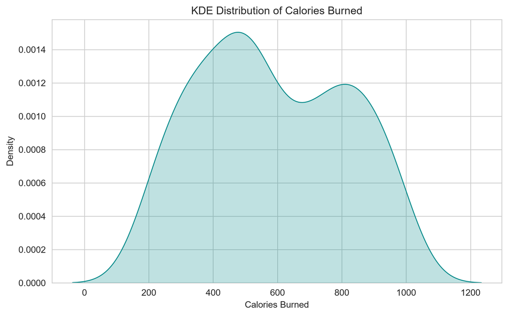

```python
call_and_show(plot_kde, df, "Calories Burned")
```

### Relationships With the Target — `plot_calories_vs_*()`

```
Figure saved: C:\Users\ayman\OneDrive\Desktop\calories-prediction\reports\figures\scatter_Running_Time(min)_vs_Calories_Burned.png
Figure saved: C:\Users\ayman\OneDrive\Desktop\calories-prediction\reports\figures\scatter_Running_Time(min)_vs_Calories_Burned.png
```

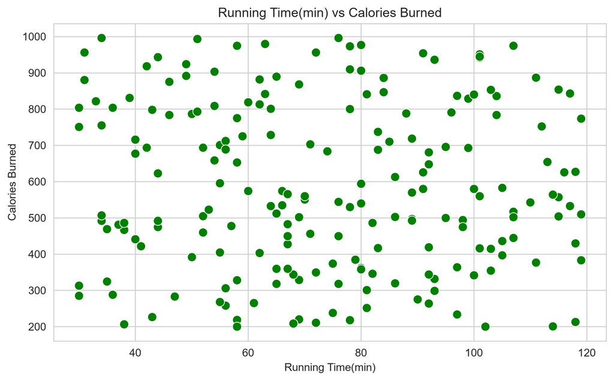

```
Figure saved: C:\Users\ayman\OneDrive\Desktop\calories-prediction\reports\figures\scatter_Distance(km)_vs_Calories_Burned.png
Figure saved: C:\Users\ayman\OneDrive\Desktop\calories-prediction\reports\figures\scatter_Distance(km)_vs_Calories_Burned.png
```

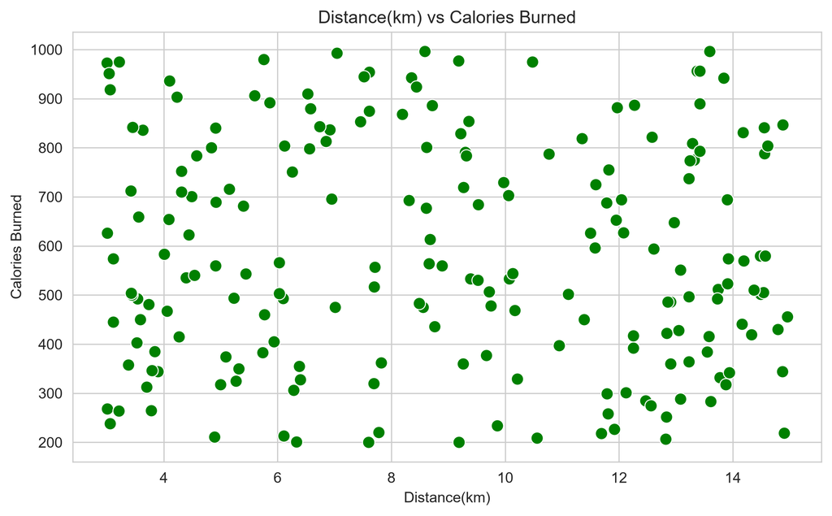

```
Figure saved: C:\Users\ayman\OneDrive\Desktop\calories-prediction\reports\figures\scatter_Average_Heart_Rate_vs_Calories_Burned.png
Figure saved: C:\Users\ayman\OneDrive\Desktop\calories-prediction\reports\figures\scatter_Average_Heart_Rate_vs_Calories_Burned.png
```

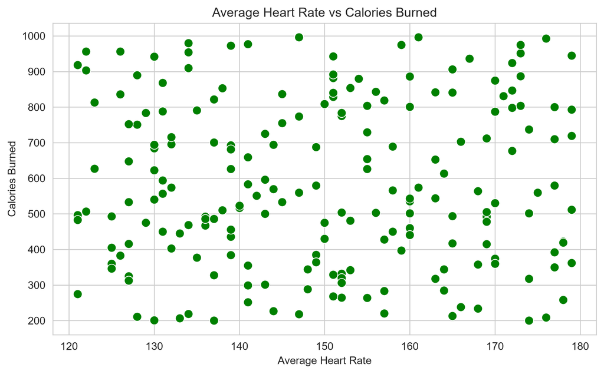

```
Figure saved: C:\Users\ayman\OneDrive\Desktop\calories-prediction\reports\figures\scatter_Weight(kg)_vs_Calories_Burned.png
Figure saved: C:\Users\ayman\OneDrive\Desktop\calories-prediction\reports\figures\scatter_Weight(kg)_vs_Calories_Burned.png
```

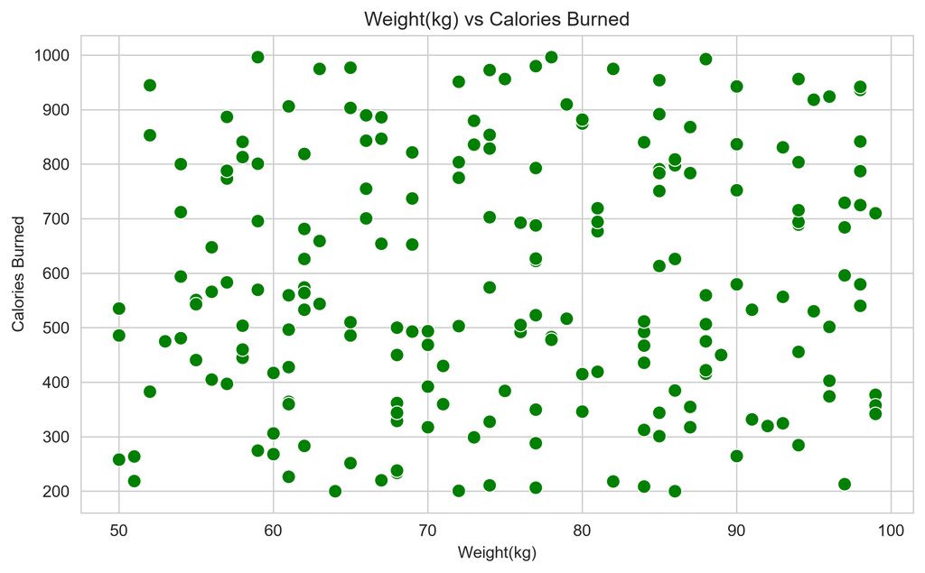

```python
call_and_show(plot_calories_vs_time, df)
call_and_show(plot_calories_vs_distance, df)
call_and_show(plot_calories_vs_heart_rate, df)
call_and_show(plot_calories_vs_weight, df)
```

### Calories vs Age — `plot_scatter()`

```
Figure saved: C:\Users\ayman\OneDrive\Desktop\calories-prediction\reports\figures\scatter_Age_vs_Calories_Burned.png
Figure saved: C:\Users\ayman\OneDrive\Desktop\calories-prediction\reports\figures\scatter_Age_vs_Calories_Burned.png
```

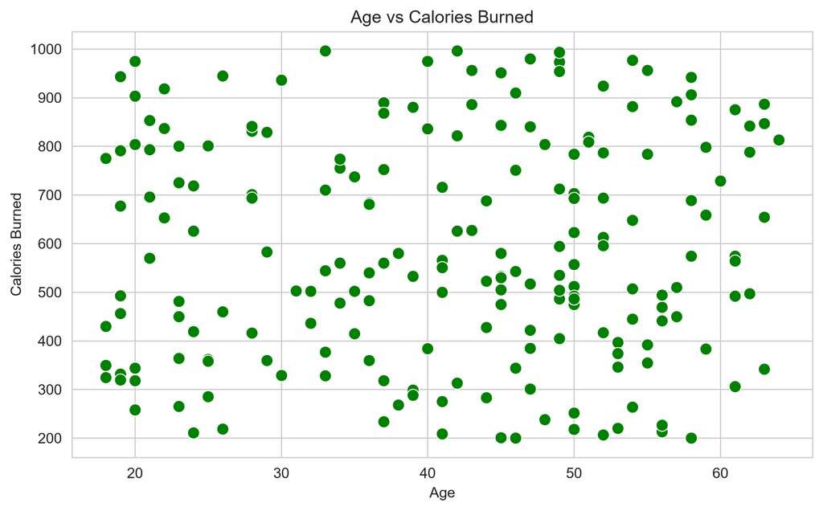

```python
call_and_show(plot_scatter, df, "Age", "Calories Burned")
```

### Feature-to-Feature Relationships — `plot_scatter()`

```
Figure saved: C:\Users\ayman\OneDrive\Desktop\calories-prediction\reports\figures\scatter_Running_Time(min)_vs_Distance(km).png
Figure saved: C:\Users\ayman\OneDrive\Desktop\calories-prediction\reports\figures\scatter_Running_Time(min)_vs_Distance(km).png
```

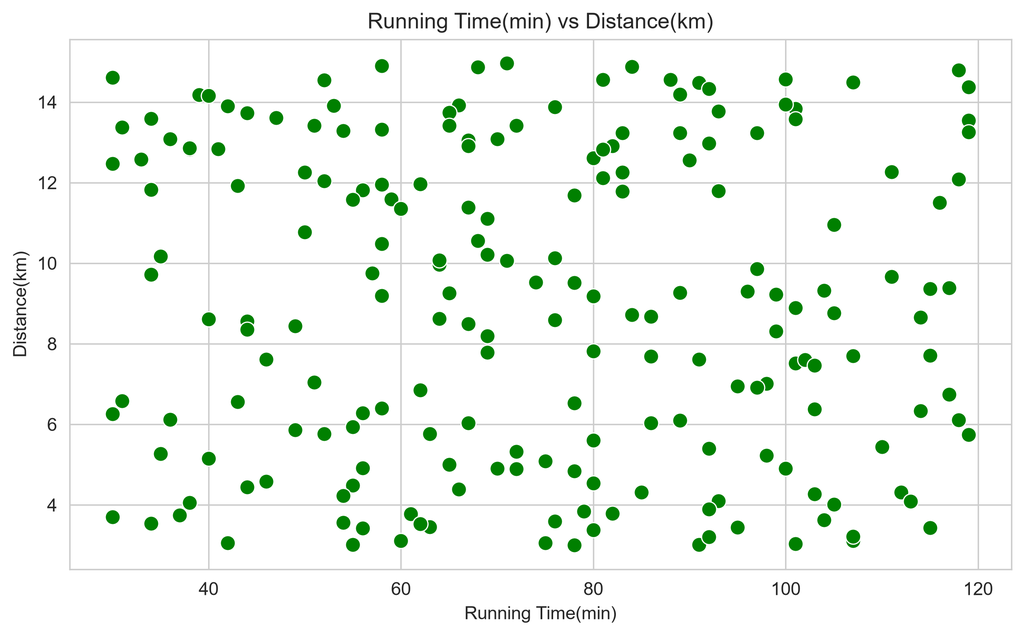

```
Figure saved: C:\Users\ayman\OneDrive\Desktop\calories-prediction\reports\figures\scatter_Running_Speed(km_h)_vs_Distance(km).png
Figure saved: C:\Users\ayman\OneDrive\Desktop\calories-prediction\reports\figures\scatter_Running_Speed(km_h)_vs_Distance(km).png
```

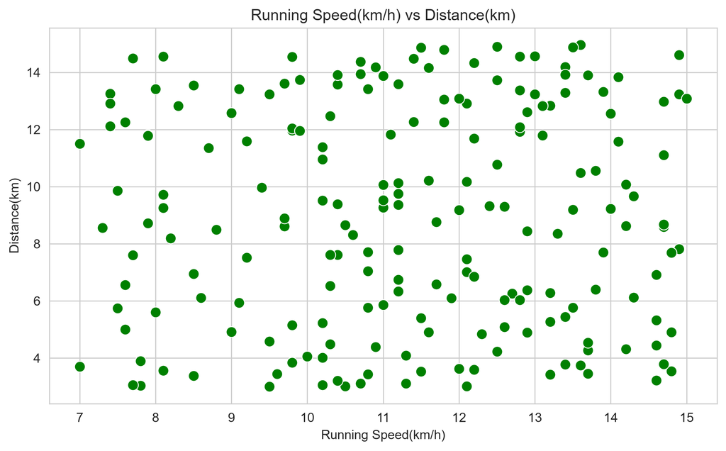

```python
call_and_show(plot_scatter, df, "Running Time(min)", "Distance(km)")
call_and_show(plot_scatter, df, "Running Speed(km/h)", "Distance(km)")
```

### Correlation Structure — `plot_correlation_heatmap()` / `plot_target_correlations()`

```
Figure saved: C:\Users\ayman\OneDrive\Desktop\calories-prediction\reports\figures\correlation_heatmap.png
Figure saved: C:\Users\ayman\OneDrive\Desktop\calories-prediction\reports\figures\correlation_heatmap.png
```

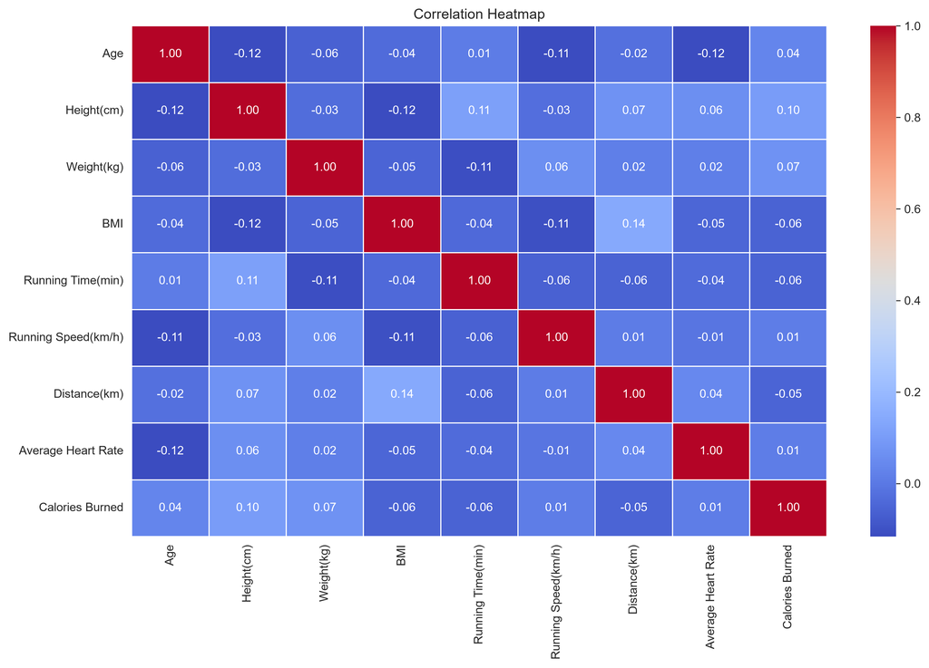

```python
call_and_show(plot_correlation_heatmap, df)
```

```
Figure saved: C:\Users\ayman\OneDrive\Desktop\calories-prediction\reports\figures\target_correlations.png
Figure saved: C:\Users\ayman\OneDrive\Desktop\calories-prediction\reports\figures\target_correlations.png
```

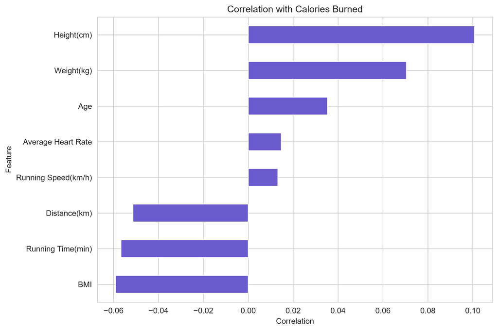

|  | Feature | Correlation | Absolute Correlation |
| --- | --- | --- | --- |
| 0 | Height(cm) | 0.100808 | 0.100808 |
| 1 | Weight(kg) | 0.070512 | 0.070512 |
| 2 | BMI | -0.059128 | 0.059128 |
| 3 | Running Time(min) | -0.056699 | 0.056699 |
| 4 | Distance(km) | -0.051363 | 0.051363 |
| 5 | Age | 0.035348 | 0.035348 |
| 6 | Average Heart Rate | 0.014701 | 0.014701 |
| 7 | Running Speed(km/h) | 0.013207 | 0.013207 |

```python
call_and_show(plot_target_correlations, df, target_column="Calories Burned")

target_correlations = (
    correlation_matrix["Calories Burned"]
    .drop("Calories Burned")
)

correlation_table = pd.DataFrame({
    "Feature": target_correlations.index,
    "Correlation": target_correlations.values,
    "Absolute Correlation": target_correlations.abs().values,
}).sort_values("Absolute Correlation", ascending=False).reset_index(drop=True)

correlation_table
```